# sus hedges correction in psych package

Remo Schmutz

2024-06-10

If and which exact hedges correction is used does not really matter for large sample sizes (I guess n>30). When decreasing the sample size in your simulation script, there are some differences between functions that should be the same (d_s).

Two of them can be corrected (MBESS, lsr), one of them uses an incorrect implementation of the hedges correction (psych)?

- In the psych package they basically just change $n$ to $n-2$ without actually applying the hedges correction. This is more of theoretical interest as I had to decrease the sample size quite a lot to see an effect.
- MBESS package: I changed `estimate = d`. It was `t` beforehand which lead to the uncorrected estimate. I changed in in this document.
- The hedges correction was missing in the simulation for the lsr package, it can be included with method = “corrected”. I changed it in this document.

This is the original code from the psych package (including comments):

```r
d <- stats$mean[2,] - stats$mean[1,]   #this is a vector differerences
sd.p <- sqrt((( (stats$n[1,]-1) * stats$sd[1,]^2) + (stats$n[2,]-1) * stats$sd[2,]^2)/(stats$n[1,]+stats$n[2,])) #if we subtract 2 from n, we get Hedges g
sd.ph <- sqrt((((stats$n[1,]-1) * stats$sd[1,]^2) + (stats$n[2,]-1) * stats$sd[2,]^2)/(stats$n[1,]+stats$n[2,]-2)) #if we subtract 2 from n, we get Hedges g
n <- stats$n[1,]+ stats$n[2,]   #this is a vector of ns taken from the statsBy function

cohen.d <- d/sd.p

hedges.g <- d/sd.ph
```

Here I used your code (changed the two things I mentioned above) to show that the psych package is the only d_s estimator that gets a different estimate (while saying they use hedges correction).

```r
cohens_d_s_mbess <- function(data, hedges_correction = TRUE){
  require(dplyr)
  require(MBESS)

  d <- MBESS::smd(Group.1 = data |> filter(timepoint == "stimulus2") |> pull(score),
                  Group.2 = data |> filter(timepoint == "stimulus1") |> pull(score),
                  Unbiased = hedges_correction)

  t <- t.test(score ~ timepoint, data = data)$statistic

  cis <- ci.smd(ncp = t,
                #smd = d,
                n.1 = data |> filter(timepoint == "stimulus2") |> pull(score) |> length(),
                n.2 = data |> filter(timepoint == "stimulus1") |> pull(score) |> length())

  res <-
    data.frame(estimate = d,
               ci_lower = cis$Lower.Conf.Limit.smd,
               ci_upper = cis$Upper.Conf.Limit.smd)

  return(res)
}

cohens_d_s_metafor <- function(data){
  # nb always applies hedges correction
  require(dplyr)
  require(tibble)
  require(metafor)

  summaries <- data |>
    group_by(timepoint) |>
    summarize(mean = mean(score),
              sd = sd(score),
              n = n()) |>
    pivot_wider(names_from = "timepoint",
                values_from = c("mean", "sd", "n"))

  fit <- escalc(measure = "SMD",
                m1i = mean_stimulus2,
                sd1i = sd_stimulus2,
                n1i = n_stimulus2,
                m2i = mean_stimulus1,
                sd2i = sd_stimulus1,
                n2i = n_stimulus1,
                data = summaries,
                append = FALSE)

  res <-
    tibble(estimate = fit$yi,
           ci_lower = fit$yi - sqrt(fit$vi)*1.96,
           ci_upper = fit$yi + sqrt(fit$vi)*1.96)

  return(res)
}

cohens_d_s_psych <- function(data, hedges_correction = TRUE){
  require(dplyr)
  require(tibble)
  require(psych)

  fit <- psych::cohen.d(score ~ timepoint,
                        data = data)

  res <-
    tibble(estimate = ifelse(hedges_correction, fit$hedges.g[2]*-1, fit$cohen.d[2]*-1),
           ci_lower = ifelse(hedges_correction, min(fit$hedges.g*-1), min(fit$cohen.d*-1)),
           ci_upper = ifelse(hedges_correction, max(fit$hedges.g*-1), max(fit$cohen.d*-1)))

  return(res)
}

cohens_d_s_lsr <- function(data){
  require(dplyr)
  require(tibble)
  require(lsr)

  # note that lsr::cohenD returns the absolute value of cohen's d, ie always positive values. fix this here to bring it in line with other packages' functions.
  mean_stimulus1 <- data |> dplyr::filter(timepoint == "stimulus1") |> summarize(mean = mean(score))
  mean_stimulus2 <- data |> dplyr::filter(timepoint == "stimulus2") |> summarize(mean = mean(score))

  d <- lsr::cohensD(score ~ timepoint,
                    data = data, method = "corrected")

  res <-
    tibble(estimate = as.numeric(ifelse(mean_stimulus1 < mean_stimulus2, d, d * -1)),
           ci_lower = NA,
           ci_upper = NA)

  return(res)
}

cohens_d_s_esc <- function(data, hedges_correction = TRUE){
  require(dplyr)
  require(tibble)
  require(esc)

  summaries <- data |>
    group_by(timepoint) |>
    summarize(mean = mean(score),
              sd = sd(score),
              n = n())

  fit <- esc::esc_mean_sd(grp1m  = summaries$mean[summaries$timepoint == "stimulus2"],
                          grp1sd = summaries$sd[summaries$timepoint == "stimulus2"],
                          grp1n  = summaries$n[summaries$timepoint == "stimulus2"],
                          grp2m  = summaries$mean[summaries$timepoint == "stimulus1"],
                          grp2sd = summaries$sd[summaries$timepoint == "stimulus1"],
                          grp2n  = summaries$n[summaries$timepoint == "stimulus1"],
                          es.type = ifelse(hedges_correction, "g", "d"))

  res <-
    tibble(estimate = fit$es,
           ci_lower = fit$ci.lo,
           ci_upper = fit$ci.hi)

  return(res)
}

cohens_d_s_esci <- function(data, hedges_correction = TRUE){
  require(dplyr)
  require(tibble)
  require(esci)

  summaries <- data |>
    group_by(timepoint) |>
    summarize(mean = mean(score),
              sd = sd(score),
              n = n())

  fit <- esci::CI_smd_ind_contrast(means = summaries$mean,
                                   sds = summaries$sd,
                                   ns = summaries$n,
                                   contrast = c(+1, -1),
                                   conf_level = 0.95,
                                   assume_equal_variance = FALSE,
                                   correct_bias = hedges_correction)

  res <-
    tibble(estimate = fit$effect_size,
           ci_lower = fit$LL,
           ci_upper = fit$UL)

  return(res)
}

cohens_d_s_effsize <- function(data, hedges_correction = TRUE){
  require(dplyr)
  require(tibble)
  require(effsize)

  fit <- effsize::cohen.d(score ~ timepoint,
                          paired = FALSE,
                          pooled = TRUE,
                          hedges.correction = hedges_correction,
                          data = data)

  res <-
    tibble(estimate = fit$estimate,
           ci_lower = fit$conf.int[1],
           ci_upper = fit$conf.int[2])

  return(res)
}

multiple_cohens_ds_for_dependent_data <- function(data, hedges_correction = TRUE){

  # Check if 'data' is a dataframe or tibble
  if (!is.data.frame(data) && !is_tibble(data)) {
    stop("The 'data' argument must be a dataframe or tibble.")
  }

  # Check for 'score' column and its type
  if (!"score" %in% names(data) || !is.numeric(data$score)) {
    stop("The 'data' must contain a numeric column named 'score'.")
  }

  # Check for 'timepoint' column, its type, and number of levels
  if (!"timepoint" %in% names(data)) {
    stop("The 'data' must contain a column named 'timepoint'.")
  }
  if (!is.factor(data$timepoint) && !is.character(data$timepoint)) {
    stop("The 'timepoint' column must be of type factor or character.")
  }

  # some pivots below assume only these columns are stimulus1sent
  data <- data |>
    select(id, timepoint, score)

  # Convert 'timepoint' to factor if it's not already
  data$timepoint <- as.factor(data$timepoint)

  # Check that 'timepoint' has exactly two levels
  if (nlevels(data$timepoint) != 2) {
    stop("The 'timepoint' column must have exactly two levels.")
  }

  results <-
    bind_rows(
      effectsize::cohens_d(score ~ timepoint, data = data, pooled_sd = TRUE, adjust = hedges_correction) |>
        as_tibble() |>
        mutate(type = "d_s",
               implementation = "{effectsize}",
               hedges_correction = hedges_correction) |>
        dplyr::select(implementation, type, hedges_correction, estimate = Hedges_g, ci_lower = CI_low, ci_upper = CI_high),

      cohens_d_s_psych(data = data, hedges_correction = hedges_correction) |>
        as_tibble() |>
        mutate(type = "d_s",
               implementation = "{psych}",
               hedges_correction = hedges_correction) |>
        dplyr::select(implementation, type, hedges_correction, estimate, ci_lower, ci_upper),

      cohens_d_s_mbess(data = data, hedges_correction = hedges_correction) |>
        mutate(type = "d_s",
               implementation = "{MBESS}",
               hedges_correction = hedges_correction) |>
        dplyr::select(implementation, type, hedges_correction, estimate, ci_lower, ci_upper),

      cohens_d_s_effsize(data = data, hedges_correction = hedges_correction) |>
        mutate(type = "d_s",
               implementation = "{effsize}",
               hedges_correction = hedges_correction) |>
        dplyr::select(implementation, type, hedges_correction, estimate, ci_lower, ci_upper),

      cohens_d_s_metafor(data = data) |>
        mutate(type = "d_s",
               implementation = "{metafor}",
               hedges_correction = TRUE) |> # nb always applies hedges correction
        dplyr::select(implementation, type, hedges_correction, estimate, ci_lower, ci_upper),

      cohens_d_s_esc(data = data, hedges_correction = hedges_correction) |>
        mutate(type = "d_s",
               implementation = "{esc}",
               hedges_correction = hedges_correction) |>
        dplyr::select(implementation, type, hedges_correction, estimate, ci_lower, ci_upper),

      cohens_d_s_esci(data = data, hedges_correction = hedges_correction) |>
        mutate(type = "d_s",
               implementation = "{esci}",
               hedges_correction = hedges_correction) |>
        dplyr::select(implementation, type, hedges_correction, estimate, ci_lower, ci_upper),

      cohens_d_s_lsr(data = data) |>
        mutate(type = "d_s",
               implementation = "{lsr}",
               hedges_correction = FALSE) |> # lsr doesn't have an option for hedges corrections
        dplyr::select(implementation, type, hedges_correction, estimate, ci_lower, ci_upper)
)

       return(results)
}

plot_different_dependent_cohens_ds <- function(parameters){
  data_for_simulations <-
    faux::rnorm_multi(n = parameters$simulation_n,
                      mu = c(stimulus1 = parameters$mean_stimulus1, stimulus2 = parameters$mean_stimulus2),
                      sd = c(parameters$sd_stimulus1, parameters$sd_stimulus2),
                      r = matrix(c(1, parameters$r_stimulus1_stimulus2,
                                   parameters$r_stimulus1_stimulus2, 1),
                                 ncol = 2)) |>
    rownames_to_column(var = "id") |>
    pivot_longer(cols = -id,
                 names_to = "timepoint",
                 values_to = "score") |>
    mutate(timepoint = fct_relevel(timepoint, "stimulus2", "stimulus1")) # ensure that factor levels are the in the correct order, especially for d_b

  simulation_results <- data_for_simulations |>
    multiple_cohens_ds_for_dependent_data() |>
    select(-hedges_correction) |>
    mutate(ci_width = ci_upper - ci_lower,
           sig = ifelse((ci_lower > 0 & ci_upper > 0) |
                          (ci_lower < 0 & ci_upper < 0) |
                          (is.na(ci_lower) & is.na(ci_upper)), TRUE, FALSE))

  plot <- ggplot(simulation_results, aes(paste(type, implementation), estimate)) +
    geom_hline(yintercept = 0, linetype = "dashed") +
    geom_linerange(aes(ymin = ci_lower, ymax = ci_upper), size = 0.8) +
    geom_point(position = position_dodge(width = 0.5), size = 1.8) +
    scale_y_continuous(breaks = scales::pretty_breaks()) +
    coord_flip() +
    theme_linedraw() +
    xlab("") +
    ylab("Cohen's d") +
    theme(legend.position = "none",
          panel.grid.minor = element_blank())


  return(plot)
}
```

## Simulation 4

Plausible parameters for preference between chocolate and poop on a 1 to 7 Likert scale. Here, we can see that we get the same estimate for each of them but for the psych implementation.

```r
set.seed(42)

parameters <-
  data.frame(simulation_n = 15,
             mean_stimulus1 = 1.5,
             mean_stimulus2 = 6.5,
             sd_stimulus1 = 1.5,
             sd_stimulus2 = 1.5,
             r_stimulus1_stimulus2 = -0.75)

parameters |>
  pivot_longer(cols = everything(),
               names_to = "parameter",
               values_to = "value") |>
  knitr::kable()
```

| parameter | value |
| --- | --- |
| simulation_n | 15.00 |
| mean_stimulus1 | 1.50 |
| mean_stimulus2 | 6.50 |
| sd_stimulus1 | 1.50 |
| sd_stimulus2 | 1.50 |
| r_stimulus1_stimulus2 | -0.75 |

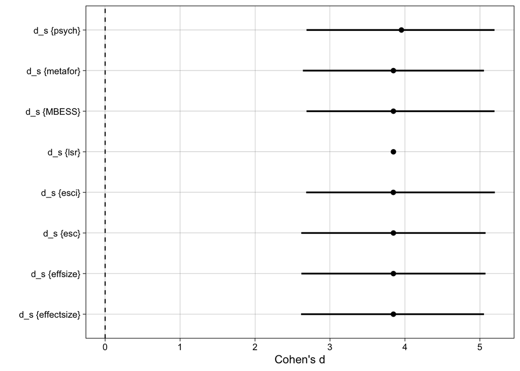

```r
plot_different_dependent_cohens_ds(parameters)
```

The estimates are all the same (with different CIs). Only the estimate from the psych package is different.